# Zákazníci eshopu

Simona Mikovčíková

2024-12-16

Cieľom analýzy bolo zistiť, aké faktory ovplyvňujú ročné výdavky zákazníkov navštevujúci eshop.

# 1 Úvod

```r
#Importovanie dat
library(readr)
data <- read_csv("C:/Users/simon/Desktop/EUBA/R/Zadanie/Zadanie c.2/Ecommerce Customers.csv")
head(data)
```

```
## # A tibble: 6 × 8
##   Email     Address Avatar `Avg. Session Length` `Time on App` `Time on Website`
##   <chr>     <chr>   <chr>                  <dbl>         <dbl>             <dbl>
## 1 mstephen… "835 F… Violet                  34.5          12.7              39.6
## 2 hduke@ho… "4547 … DarkG…                  31.9          11.1              37.3
## 3 pallen@y… "24645… Bisque                  33.0          11.3              37.1
## 4 riverare… "1414 … Saddl…                  34.3          13.7              36.7
## 5 mstephen… "14023… Mediu…                  33.3          12.8              37.5
## 6 alvarezn… "645 M… Flora…                  33.9          12.0              34.5
## # ℹ 2 more variables: `Length of Membership` <dbl>, `Yearly Amount Spent` <dbl>
```

Dataset obsahuje 8 premenných:

- Email: E-mailová adresa zákazníka.
- Address: Adresa zákazníka.
- Avatar: Preferovaný avatar alebo farba zákazníka.
- Avg. Session Length: Priemerná dĺžka jednej návštevy (v minútach).
- Time on App: Čas strávený na mobilnej aplikácii (v minútach)
- Time on Website: Čas strávený na webovej stránke (v minútach).
- Length of Membership: Dĺžka členstva zákazníka (v rokoch).
- Yearly Amount Spent: Suma, ktorú zákazník ročne utratí (v dolároch).

```r
# Kontrola chýbajúcich hodnôt
sum(is.na(data))
```

```
## [1] 0
```

# 2 Exploratorná dátová analýza (EDA)

```r
# Popisné štatistiky
summary(data)
```

```
##     Email             Address             Avatar          Avg. Session Length
##  Length:500         Length:500         Length:500         Min.   :29.53
##  Class :character   Class :character   Class :character   1st Qu.:32.34
##  Mode  :character   Mode  :character   Mode  :character   Median :33.08
##                                                           Mean   :33.05
##                                                           3rd Qu.:33.71
##                                                           Max.   :36.14
##   Time on App     Time on Website Length of Membership Yearly Amount Spent
##  Min.   : 8.508   Min.   :33.91   Min.   :0.2699       Min.   :256.7
##  1st Qu.:11.388   1st Qu.:36.35   1st Qu.:2.9304       1st Qu.:445.0
##  Median :11.983   Median :37.07   Median :3.5340       Median :498.9
##  Mean   :12.052   Mean   :37.06   Mean   :3.5335       Mean   :499.3
##  3rd Qu.:12.754   3rd Qu.:37.72   3rd Qu.:4.1265       3rd Qu.:549.3
##  Max.   :15.127   Max.   :40.01   Max.   :6.9227       Max.   :765.5
```

- Avg. Session Length (Priemerná dĺžka jednej návštevy):
  - Rozpätie hodnôt: 29.53 - 36.14 minút
  - Priemer: 33.05
- Time on App (Čas strávený v aplikácii):
  - Rozpätie hodnôt: 8.508 - 15.127 minút
  - Priemer: 12.052 minút
- Time on Website (Čas strávený na webstránke):
  - Rozpätie hodnôt:: 33.91 - 40.01 minút.
  - Priemer: 37.06
- Length of Membership (Dĺžka členstva):
  - Rozpätie hodnôt:: 0.2699 - 6.9227 rokov
  - Priemer: 3.5335
- Yearly Amount Spent (Ročné výdavky):
  - Rozpätie hodnôt:: 256.7 - 765.5 dolárov
  - Priemer: 499.3 dolárov

```r
#vyčisenie databázy
data_clean <- data %>%
  select(-Email, -Address, -Avatar)
```

Odstránili sme premenné email, adresa a avatar pretože obsahujú textovú informáciu ktorá neprispieva k celkovej analýze dát. Zameriame sa na numerické premenné a to na priemernú dĺžku jednej návštevy, čas strávený v aplikácii, čas strávený na webstránke, dĺžka členstva a ročné výdavky.

## 2.1 Vizualizácia dát

### 2.1.1 Distribúcia numerických premenných

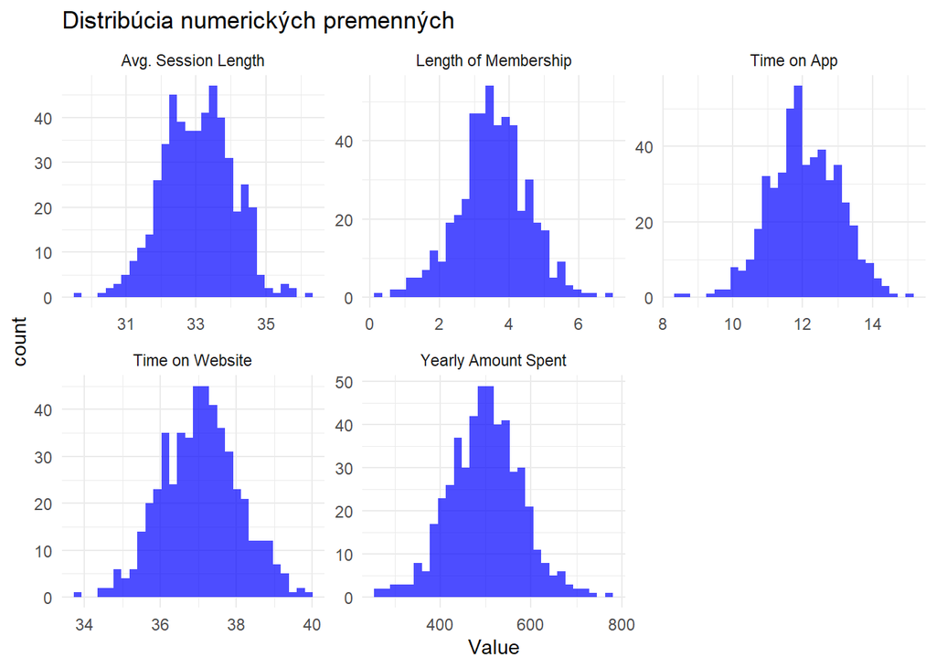

```r
# Histogramy pre všetky numerické premenné
data_clean %>%
  pivot_longer(everything(), names_to = "Variable", values_to = "Value") %>%
  ggplot(aes(x = Value)) +
  geom_histogram(bins  = 30,  fill = "blue", alpha = 0.7) +
  facet_wrap(~ Variable, scales = "free") +
  theme_minimal() +
  labs(title = "Distribúcia numerických premenných")
```

Väčšina premenných má symetrické rozdelenie.

### 2.1.2 Vzťahy medzi premennými

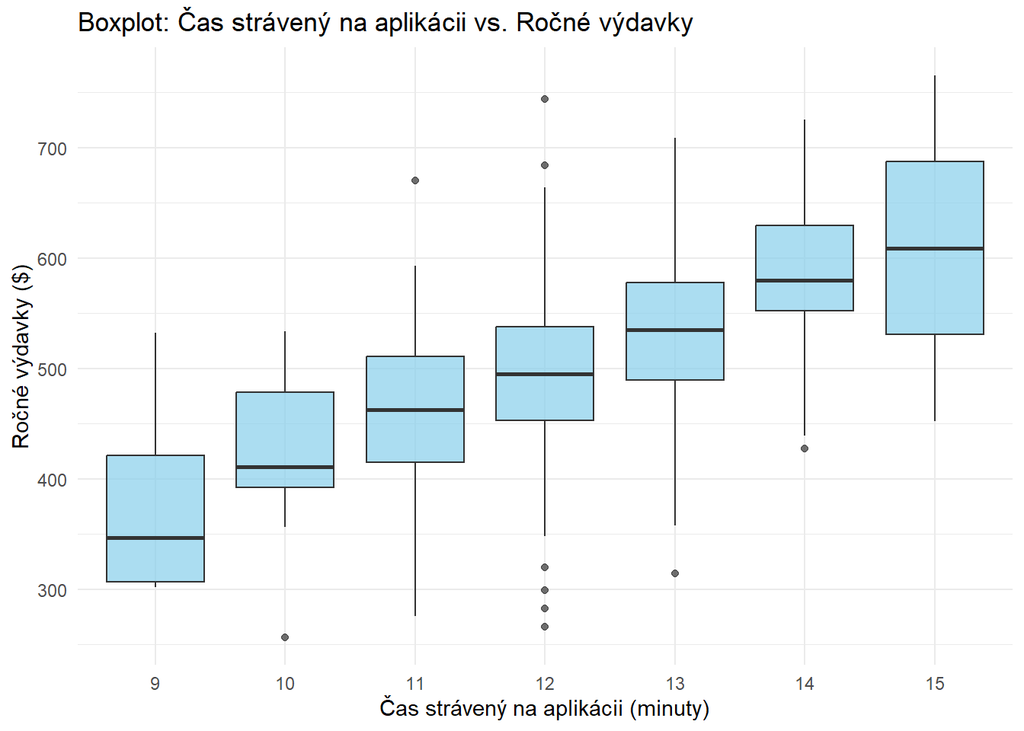

```r
# Boxplot pre Time.on.App a Yearly Amount Spent
ggplot(data_clean, aes(x = as.factor(round(`Time on App`)), y = `Yearly Amount Spent`)) +
  geom_boxplot(fill = "skyblue", alpha = 0.7) +
  theme_minimal() +
  labs(title = "Boxplot: Čas strávený na aplikácii vs. Ročné výdavky",
       x = "Čas strávený na aplikácii (minuty)",
       y = "Ročné výdavky ($)")
```

So zvyšujúcim časom stráveným na aplikácíí, medián ročných výdavkov rastie. Napríklad zákazníci, ktorí strávia 9 minút, majú medián výdavkov okolo 350 USD, zatiaľ čo zákazníci, ktorí strávia 15 minút, majú medián výdavkov približne 600 USD.

Boxplot naznačuje, že zákazníci, ktorí trávia viac času na aplikácii, majú tendenciu míňať viac.

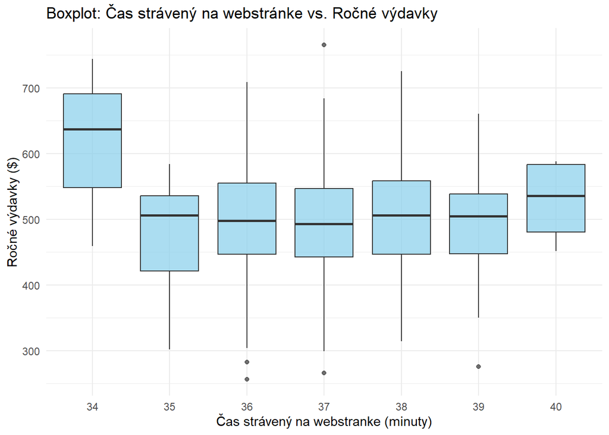

```r
# Boxplot pre Time on Website a Yearly Amount Spent
ggplot(data_clean, aes(x = as.factor(round(`Time on Website`)), y = `Yearly Amount Spent`)) +
  geom_boxplot(fill = "skyblue", alpha = 0.7) +
  theme_minimal() +
  labs(title = "Boxplot: Čas strávený na webstránke vs. Ročné výdavky",
       x = "Čas strávený na webstranke (minuty)",
       y = "Ročné výdavky ($)")
```

V porovnaní s časom stráveným na aplikácii čas strávený na webstránke nemá taký silný pozitívny vplyv na ročné výdavky zákazníkov. Aj keď existujú drobné rozdiely (najmä pri 34 hodinách), celkový trend je menej výrazný.

```r
# Transformácia dát do "long" formátu
data_clean_long <- data_clean %>%
  pivot_longer(
    cols = c(`Length of Membership`, `Time on App`,`Avg. Session Length`, `Time on Website`),#Vyberieme stĺpce, ktoré chceme zmeniť na riadky
    names_to = "Variable", # Názvy pôvodných stĺpcov uložíme do nového stlpca Variable
    values_to = "Value" # Hodnoty z vybraných stĺpcov uložíme do nového stĺpca Value
  )
```

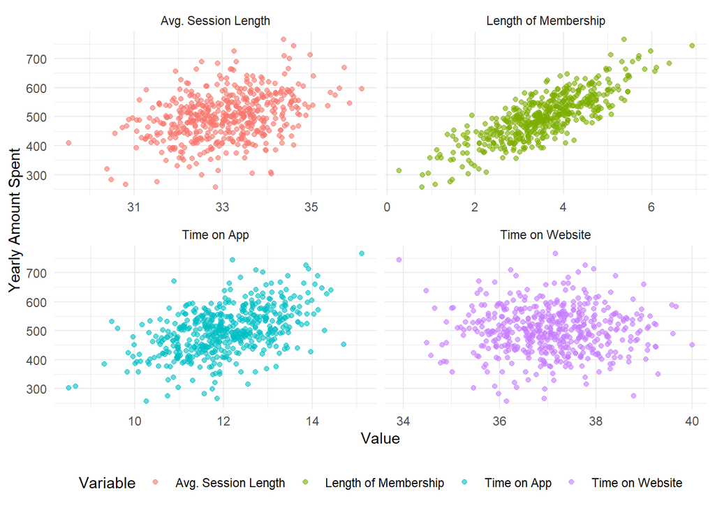

```r
# Bodový graf
ggplot(data_clean_long , aes(x = Value, y = `Yearly Amount Spent`, color = Variable)) +
  geom_point(alpha = 0.6) +
  facet_wrap(~ Variable, scales = "free_x") +
  theme_minimal() +
  theme(legend.position = "bottom")
```

Na bodovom grafe vidíme pozitívny lineárny vzťah medzi dĺžkou predplatného a ročnými výdavkami.

# 3 Korelačná analýza

```r
# Korelačná matica pre numerické premenné
cor_matrix <- cor(data_clean)
cor_matrix
```

```
##                      Avg. Session Length Time on App Time on Website
## Avg. Session Length           1.00000000 -0.02782598    -0.034986900
## Time on App                  -0.02782598  1.00000000     0.082388273
## Time on Website              -0.03498690  0.08238827     1.000000000
## Length of Membership          0.06024739  0.02914256    -0.047581819
## Yearly Amount Spent           0.35508829  0.49932777    -0.002640845
##                      Length of Membership Yearly Amount Spent
## Avg. Session Length            0.06024739         0.355088295
## Time on App                    0.02914256         0.499327770
## Time on Website               -0.04758182        -0.002640845
## Length of Membership           1.00000000         0.809083568
## Yearly Amount Spent            0.80908357         1.000000000
```

Z korelačnej matice vidíme, že premenné Length of Membership (Dĺžka členstva) a Yearly Amount Spent (Ročné výdavky zákazníka) sú *silne pozitívne korelované* (0.809). To znamená, že zákazníci s dlhším členstvom majú tendenciu míňať viac peňazí ročne.

Medzi premennými Time on App(Čas strávený na aplikácii) a Yearly Amount Spent (Ročné výdavky zákazníka) sú *stredne silne pozitívne korelované* (0.499). Znamená to, že čím viac času strávi zákazník na aplikácii, tým viac peňazí pravdepodobne minie.

Medzi premennými Avg. Session Length(Priemerná dĺžka jednej návštevy) Yearly Amount Spent (Ročné výdavky zákazníka) sú *stredne silne pozitívne korelované* (0.355). To naznačuj, dĺžka jednej relácie je mierne pozitívne spojená s výdavkami zákazníka.

Time on Website(Čas strávený na webstránke) a Yearly Amount Spent(Ročné výdavky zákazníka) má zanedbateľnú koreláciu.

# 4 Regresné modelovanie

## 4.1 Rozdelenie dát na tréningový a testovací subor

```r
#Rozdeľte dáta na tréninovací(80) a testovací súbor(20)
set.seed(101)
data_split <- initial_split(data_clean, prop = 0.8)
train_data <- training(data_split) #400
test_data <- testing(data_split)#100
```

## 4.2 Odhad modelu (lineárna regresia)

```r
# Lineárny regresný model
lm_model <- lm(`Yearly Amount Spent`~.,data = train_data)

# Zhrnutie modelu
summary(lm_model)
```

```
##
## Call:
## lm(formula = `Yearly Amount Spent` ~ ., data = train_data)
##
## Residuals:
##      Min       1Q   Median       3Q      Max
## -30.2330  -6.4535   0.0262   6.6834  30.8819
##
## Coefficients:
##                          Estimate Std. Error t value Pr(>|t|)
## (Intercept)            -1042.5616    26.0562 -40.012   <2e-16 ***
## `Avg. Session Length`     25.6069     0.5110  50.109   <2e-16 ***
## `Time on App`             38.5656     0.5160  74.746   <2e-16 ***
## `Time on Website`          0.3975     0.5108   0.778    0.437
## `Length of Membership`    61.0581     0.5330 114.564   <2e-16 ***
## ---
## Signif. codes:  0 '***' 0.001 '**' 0.01 '*' 0.05 '.' 0.1 ' ' 1
##
## Residual standard error: 10.19 on 395 degrees of freedom
## Multiple R-squared:  0.9821, Adjusted R-squared:  0.9819
## F-statistic:  5427 on 4 and 395 DF,  p-value: < 2.2e-16
```

Ak všetky ostatné faktory zostanú konštantné, zvýšenie “Priemernej dĺžky relácie” (Avg. Session Length) o jednu jednotku zvýši ročné výdavky zákazníka o približne 25,6 USD.

Podobne, zvýšenie “Času stráveného v aplikácii” (Time on App) o jednu jednotku zvýši ročné výdavky zákazníka o 38,5 USD.

Zvýšenie “Času stráveného na webovej stránke” (Time on Website) o jednu jednotku zvýši ročné výdavky iba o približne 0,4 USD.

Najväčší nárast, približne 61 USD pri zvýšení “Dĺžky členstva” (Length of Membership) o jednu jednotku.

Multiple R-squared: 0.9821 Model vysvetľuje 98.21 % variability v závislej premennej.

Residual Standard Error: 10.19  
Priemerná chyba medzi skutočnými a predikovanými hodnotami je približne 10.19 dolárov.

F-statistic: p-hodnota < 2.2e-16  
Modelje štatisticky významný.

## 4.3 Predikcie a hodnotenie modelu

```r
# Predikcie na testovacích dátach
predictions <- predict(lm_model, newdata = test_data, type = "response")
#Metriky
mse <- mean((test_data$`Yearly Amount Spent` - predictions)^2)
print(paste("Mean Squared Error (MSE):", mse))
```

```
## [1] "Mean Squared Error (MSE): 84.05215727489"
```

```r
rmse <- sqrt(mse)
print(paste("Root Mean Squared Error (RMSE):", rmse))
```

```
## [1] "Root Mean Squared Error (RMSE): 9.16799636097714"
```

```r
r2 <- cor(test_data$`Yearly Amount Spent`, predictions)^2
print(paste("R-squared:", r2))
```

```
## [1] "R-squared: 0.989755266264677"
```

```r
mae <- mean(abs(test_data$`Yearly Amount Spent` - predictions))
print(paste("Mean Absolute Error (MAE):", mae))
```

```
## [1] "Mean Absolute Error (MAE): 7.47597165824263"
```

Model má priemernú odchýlku v predikciách okolo 84.  
Model má priemernú chybu predikcie približne 9.17 dolárov. Model vysvetľuje približne 98.98 % variability v závislej premennej (Yearly.Amount.Spent(Ročné výdavky zákazníka)).  
Model má priemernú chybu predikcie približne 7.48 dolárov.  
Model má veľmi dobrú prognostickú schopnosť, čo je vidieť na vysokom R² a relatívne nízkych chybách (MSE, RMSE a MAE).

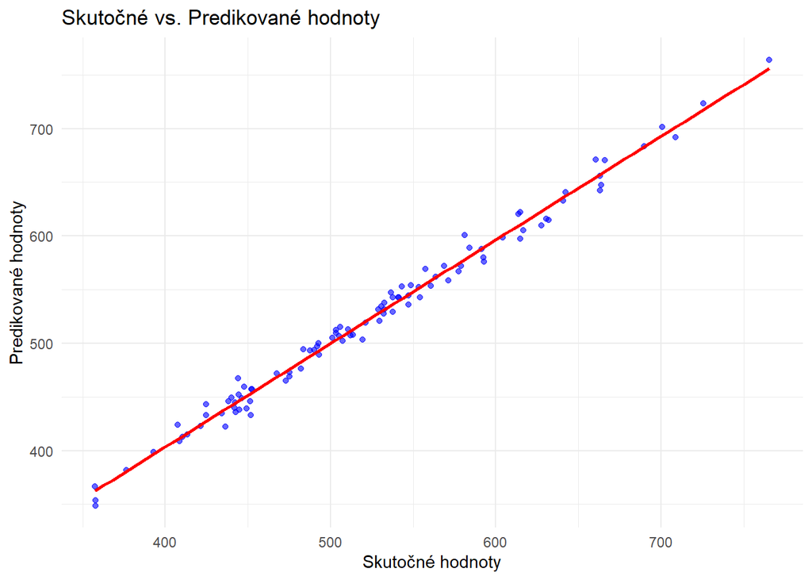

```r
# Vizualizácia skutočných vs. predikovaných hodnôt
ggplot() +
  geom_point(aes(x = test_data$`Yearly Amount Spent`, y = predictions), alpha = 0.6, color = "blue") +
  stat_smooth(aes(x = test_data$`Yearly Amount Spent`, y = predictions),
              method = "lm", formula = y ~ x, color = "red", se = FALSE) +
  theme_minimal() +
  labs(
    title = "Skutočné vs. Predikované hodnoty",
    x = "Skutočné hodnoty",
    y = "Predikované hodnoty"
  )
```

Graf ukazuje, že lineárny regresný model dokáže veľmi dobre predikovať hodnoty Yearly Amount Spent, čo je v súlade s vysokou hodnotou R-squared (0.989).